# Bootstrap analysis of top performers

Robert Allaway, Sage Bionetworks

2020-03-03

In order to declare top-performers for a DREAM challenge, we need to assess if there are any “tied” methods, that is, methods that are not substantially different in performance. We determine this using a bootstrapping (sampling with replacement) approach to determing how a submission would score in different scenarios (that is - when only considering resampled sets of the values to be predicted). For the CTD<sup>2</sup> challenge, we can do this by sampling the compounds for which targets had to be predicted. Specifically, we sample with replacement all of the submitted predictions and the gold standard and score the prediction files. We repeat this for at total of 1000 samples to obtain a distribution of scores for each participant. We then calculate a Bayes factor relative to the best-scoring method, to see if any of the other methods are within a certain threshold. Smaller Bayes factors indicate more similar performance while larger Bayes factors indicate more disparate performance. We use a Bayes factor of 3 as a cutoff to indicate a tie.

Unfold the code if you want to see how we do this.

First, import packages for data manipulation and retrieve prediction data, gold standard data, and the template for use in the scoring code. Also, define the fraction overlap function for calculating SC1 scores.

```r
library(dplyr)
library(magrittr)
library(readr)
library(tidyr)
library(purrr)
library(ggplot2)
library(synapser)
library(forcats)
synLogin()
```

```
## Welcome, Robert Allaway!
```

```r
query <- synTableQuery('select * from syn21628283 where submissionId < 9699164')$asDataFrame()
```

```
##
Create CSV FileHandle [##########----------]50.00%   10/20
Create CSV FileHandle [####################]100.00%   20/20   Done...
Downloading  [####################]100.00%   772.0bytes/772.0bytes (261.1kB/s) Job-108632372245972743611427735.csv Done...
```

```r
prediction_paths <- sapply(query$id, function(x){
  synGet(x)$path
})

suppressMessages(setNames(prediction_paths, query$teamId))
```

```
##                                                                  3383488
##               "/Users/robert/.synapseCache/154/49564154/template_v4.csv"
##                                                                     <NA>
##                    "/Users/robert/.synapseCache/156/49564156/output.csv"
##                                                                  3401316
##                "/Users/robert/.synapseCache/158/49564158/prediction.csv"
##                                                                  3404087
##         "/Users/robert/.synapseCache/160/49564160/final_predictions.csv"
##                                                                  3403678
## "/Users/robert/.synapseCache/162/49564162/DMIS_PDA_submission_final.csv"
##                                                                     <NA>
##               "/Users/robert/.synapseCache/164/49564164/predictions.csv"
##                                                                  3401376
##     "/Users/robert/.synapseCache/166/49564166/finalSubmissionSignal.csv"
##                                                                  3404084
##               "/Users/robert/.synapseCache/168/49564168/predictions.csv"
##                                                                  3404089
##            "/Users/robert/.synapseCache/7/49861007/template_base_v2.csv"
##                                                                  3400788
##                "/Users/robert/.synapseCache/172/49564172/prediction.csv"
```

```r
frac_overlap <- function(gold, pred){
  sum(gold %in% pred)/length(gold)
}

gold_path <- synGet("syn21302164")$path
template_path <- synGet('syn21321426')$path
```

Define the targets that we have reliable information on and will score based on.

```r
targs <- c("EGFR","CSNK2A2","BMP2K","AAK1","Q6ZSR9","GAK","PRKD2","PRKD3","SIK2","SIK3","PLK4","AURKA","AURKB","PTK2",
             "FER","PTK2B","TNK1","TNK2","MAP2K5","MAP2K1","MAP2K2","PDGFRB","STK10","SLK","MAP4K2","MAP4K5","MAP4K3",
             "MET","CDK2","CDK5","CDK16","CDK9","GSK3A","GSK3B","CDK7","ERCC2","CDK1","CDK12","CDK13","CLK1","DYRK1A",
             "CDK17","CDK4","CDK6","FGFR1","MAPK10","MAPK8","MAPK9","ADCK1","STK16","NEK9","FECH","CSNK1A1","CSNK1E",
             "CSNK1D","MAP3K4","WEE1","MST1R","PIP4K2C","IRAK1","TAOK3","PIM1","TAOK1","CIT","PRKX","PRKY","CDC42BPA",
             "CDC42BPB","PRKACA","PRKACB","PRKCQ","CLK4","PAK6","PRKACG","RPS6KB1","MAPK7","PRKG1","PRKCI","CDKL5","CDK18",
             "ADRBK1","STK11","EPHB3","BRAF","NLK","TGFBR2","CSK","MYLK","FGR","TESK1","KIT","ULK1","FES","IGF1R","INSR",
             "JAK2","STK26","CAMK4","TAOK2","EIF2AK1","ICK","CSNK1G2","CSNK1G1","CSNK1G3","CLK2","TP53RK","MINK1","MAPK15",
             "ERN1","MAP2K6","MAP3K5","MAP3K6","MAP2K3","ERN2","MAPK1","MAPK3","AKT3","AKT1","AKT2","RPS6KA5","ACVRL1",
             "MAPKAPK5","NEK1","ARAF","ACAD10","ADCK3","ACVR2B","PAK2","CLK3","MAPKAPK3","PLK1","PDXK","DCK","ADK","PKMYT1",
             "NUAK2","HSP90AB2P","STK24","CMPK1","GARS","ACOX3","ACAD11","DCTPP1","NEK7","SMC2","TOP2B","MYH10","PIM2",
             "CAMK1G","PIP4K2A","PIP4K2B","AK2","NME2","CDC42BPG","AP1G1","DHCR24","SLC25A5","ACTR3","SNRNP200",
             "CARS","DNAJA1","PFKP","MAT2A","IPO7","STK38L","AIMP1","CDC7","PRKAR2A","EPHA1","EPHA7","BMPR1B","BMPR1A",
             "TYK2","BMPR2","MAP3K2","MAP3K3","SYK","NEK3","BUB1","LATS1","MAP3K11","IKBKE","TBK1","STK4","STK3","CDK3",
             "MARK4","MELK","IRAK4","RPS6KA4","RPS6KA1","RPS6KA3","MARK2","MARK3","RPS6KA6","PRKAG2","PRKAA1","PRKAG1","PAK4",
             "CHEK1","NTRK1","CAMK2D","CAMK2G","CAMKK2","PHKG2","MAP4K4","TNIK","MYLK3","MAP4K1","JAK1","ULK3","PRKCD",
             "PRKCA","PRKCB","PKN1","PKN2","ROCK2","ROCK1","NQO2","ACVR1","IRAK3","FLT3","RET","DDR1","DDR2","ABL2","BCR",
             "ABL1","RIPK2","MAPKAPK2","MAPK11","MAPK14","ZAK","RIPK3","YES1","LCK","SRC","FYN","HCK","LYN","FRK","EPHA2",
             "EPHA5","EPHB2","EPHB4","EPHA4","BTK","TEC","MAP3K1","LIMK1","LIMK2","PTK6","EPHB6","ACVR1B","TGFBR1")
```

Read in prediction files, slice out top 10 predictions for each compound, and nest dataframes. Then bootstrap the predictions, a gold standard, and a null model 1000 times to calculate 1000 p-values per prediction.

```r
  gold <- suppressMessages(read_csv(gold_path)) %>% filter(target %in% targs)


  template <- read_csv(template_path) %>% filter(target %in% targs)

  ###SC1

  gold_df <- gold %>%
    select(-cmpd) %>%
    group_by(cmpd_id) %>%
    nest() %>%
    arrange(cmpd_id)

  pred_df<- lapply(names(prediction_paths), function(x){
    read_csv(prediction_paths[[x]]) %>%
      gather(cmpd_id, confidence ,-target) %>%
      filter(target %in% targs) %>%
      group_by(cmpd_id) %>%
      arrange(-confidence, target) %>%
      slice(1:10) %>%  ##instead of top n. We eliminate ties alphabetically!
      nest() %>%
      arrange(cmpd_id) %>%
      rename({{x}} := data)
  }) %>% reduce(left_join, by = 'cmpd_id')


  sc1_vals <- sapply(1:1000, function(x){

    null_model <- template %>%
      gather(cmpd_id, confidence ,-target) %>%
      group_by(cmpd_id) %>%
      arrange(-confidence, target) %>%
      sample_n(10, replace = F) %>%
      select(-confidence) %>%
      set_names(c('target', 'cmpd_id')) %>%
      filter(target %in% targs) %>%
      nest() %>%
      ungroup() %>%
      mutate(cmpd_id= 1:32) %>%
      rename(null = data)


   join <- inner_join(gold_df, pred_df, by = 'cmpd_id') %>%
    ungroup() %>%
     sample_n(32, replace = T) %>%
     mutate(cmpd_id= 1:32) %>%
     inner_join(null_model) %>%
     select(-cmpd_id)

   the_names <- colnames(join)

   join <- join %>%
     map(., function(a){
       map2(.$data, a, function(x,y){
       frac_overlap(x$target, y$target)
       }) %>% plyr::ldply()
     }) %>% bind_cols

   colnames(join) <- the_names

   ps <- join %>%
     apply(., 2, function(x){
       wilcox.test(x = x, y= .$null, paired = T, exact = NULL)$p.value
       })


    if(any(is.nan(ps))){
      ps[is.nan(ps)] <- 1
    }
    ps

  }) %>% t()

  # sc1 <- mean(-log2(sc1_vals)) %>% signif(5)

  sc1 <- sc1_vals %>%
    as_data_frame() %>%
    gather(submission, bs_score)
```

Repeat, but for SC2, which is the significance of the target ranks as compared to a null model.

```r
  ##SC2


   pred_df<- lapply(names(prediction_paths), function(x){
     read_csv(prediction_paths[[x]]) %>%
       gather(cmpd_id, confidence ,-target) %>%
       filter(target %in% targs) %>%
       group_by(cmpd_id) %>%
       arrange(-confidence, target) %>%  ##instead of top n. We eliminate ties alphabetically!
       nest() %>%
       arrange(cmpd_id) %>%
       rename({{x}} := data)
   }) %>% reduce(left_join, by = 'cmpd_id')

  sc2_vals <- sapply(1:1000, function(x){

    null_model <- template %>%
      gather(cmpd_id, confidence ,-target) %>%
      group_by(cmpd_id) %>%
      arrange(-confidence, target) %>%
      sample_frac(1, replace = F) %>%
      select(-confidence) %>%
      set_names(c('target', 'cmpd_id')) %>%
      filter(target %in% targs) %>%
      nest() %>%
      ungroup() %>%
      mutate(cmpd_id= 1:32) %>%
      rename(null = data)

    join <- inner_join(gold_df, pred_df, by = 'cmpd_id') %>%
      ungroup() %>%
      sample_n(32, replace = T) %>%
      mutate(cmpd_id= 1:32) %>%
      inner_join(null_model) %>%
      select(-cmpd_id)

    the_names <- colnames(join)

    join <- join %>%
      map(., function(a){
        map2(.$data, a, function(x,y){
          match(x$target, y$target) %>% unique()
        }) %>% unlist()
      }) %>% bind_rows


    colnames(join) <- the_names

    ps <- join %>%
      apply(., 2, function(x){
        wilcox.test(x = x, y= .$null, paired = T, exact = NULL)$p.value
      })


    if(any(is.nan(ps))){
      ps[is.nan(ps)] <- 1
    }
    ps

  }) %>% t()

   sc2 <- sc2_vals %>%
    as_data_frame() %>%
    gather(submission, bs_score)
```

Use our `challengescoring` package to compute Bayes factors using a matrix of scores for SC1 and SC2, setting the `refPredIndex` as the number of the column that contains the top prediction (the reference prediction).

```r
  sc1_bf <- challengescoring::computeBayesFactor(bootstrapMetricMatrix = sc1_vals, refPredIndex = 5, invertBayes = F) %>%
    as_tibble(rownames = "submission") %>%
    rename(bayes = value)

  sc2_bf <- challengescoring::computeBayesFactor(bootstrapMetricMatrix = sc2_vals, refPredIndex = 10, invertBayes = F) %>%
  as_tibble(rownames = "submission") %>%
    rename(bayes = value)
```

Then plot SC1 results. Red indicates the reference model, orange indicates a Bayes factor of 3-5, grey indicates a Bayes factor of >5.

```r
sc1_final <- sc1 %>%
  filter(!submission %in% c('data','null')) %>%
  left_join(sc1_bf) %>%
  mutate(bayes_category = case_when(bayes == 0 ~ 'Reference',
                                    bayes <3 ~ '<3',
                                    bayes>3 & bayes<5 ~ '3-5',
                                    bayes>5 ~ ">5"))
```

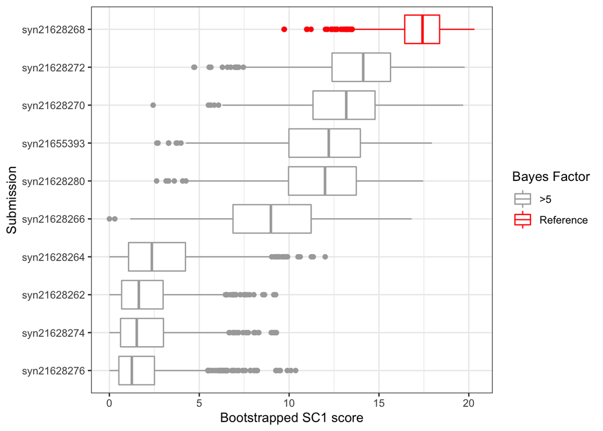

```r
ggplot(sc1_final) +
    geom_boxplot(aes(x = fct_reorder(submission, -bs_score), y = -log2(bs_score), color = bayes_category)) +
    theme_bw() +
  scale_color_manual(values = c("Reference"="red","3-5" = "orange", ">5"= "darkgrey"),
                     name = "Bayes Factor") +
  coord_flip() +
  labs(y = 'Bootstrapped SC1 score', x = 'Submission')
```

Looking at these results, the top performer is not tied with any other valid submission.

Then plot SC2 results. Red indicates the reference model, orange indicates a Bayes factor of 3-5, grey indicates a Bayes factor of >5.

```r
sc2_final <- sc2 %>%
  filter(!submission %in% c('data','null')) %>%
  left_join(sc2_bf) %>%
  mutate(bayes_category = case_when(bayes == 0 ~ 'Reference',
                                    bayes <3 ~ '<3',
                                    bayes>3 & bayes<5 ~ '3-5',
                                    bayes>5 ~ ">5"))
```

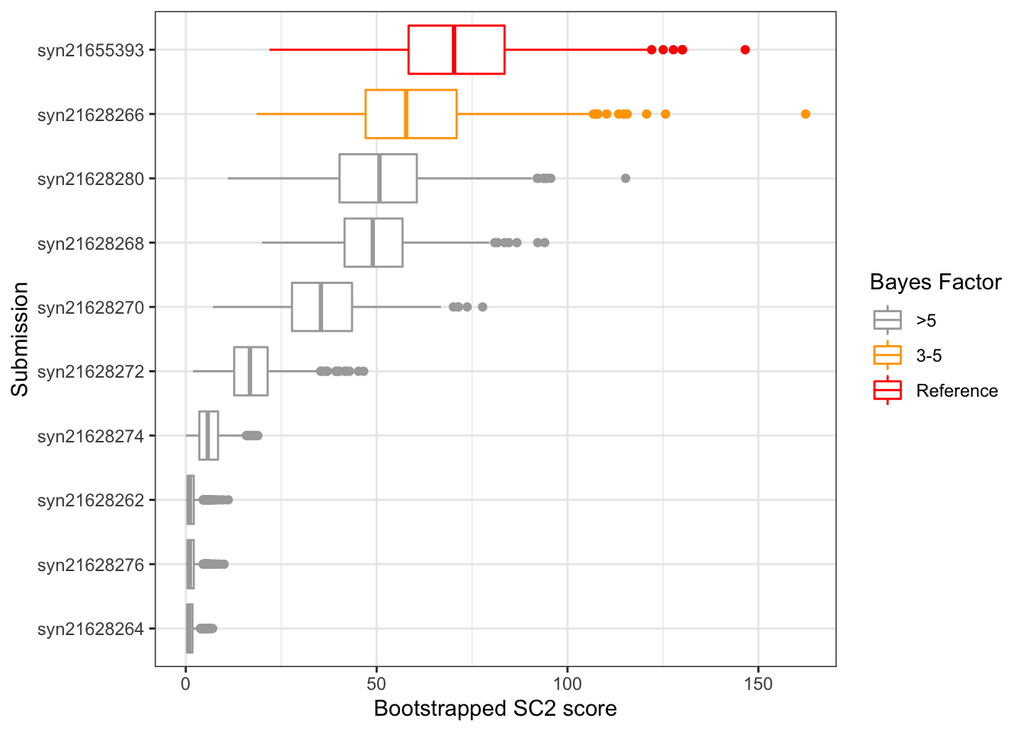

```r
ggplot(sc2_final) +
    geom_boxplot(aes(x = fct_reorder(submission, -bs_score), y = -log2(bs_score), color = bayes_category)) +
  theme_bw() +
  scale_color_manual(values = c("Reference"="red","3-5" = "orange", ">5"= "darkgrey"),
                     name = "Bayes Factor") +
  coord_flip() +
  labs(y = 'Bootstrapped SC2 score', x = 'Submission')
```

Looking at these results, the top performer is not tied with any other valid submission, though one comes close to a tie.